# Inferential Statistics: Exploration of the Stroop Effect

Tyler C Julian

February 19, 2018

### Independent and Dependent variables

The **independent variable** for this experiment would be the the conditions of the words. They change from congruent to incongruent between the two trials.

The **dependent variable** would the the amount of time it takes a participant to complete the test. This is measured in seconds.

### Hypothesis and Statistical Test

The **null hypothesis** for this experiment is that there will not be a statistical difference in the average time between the congruent and incongruent conditions.

The **alternative hypothesis** is that there will be a statistical difference in the average time between the congruent and incongruent conditions.

These hypotheses can be pictured below, with *H<sub>0</sub>* being the null hypothesis, *H<sub>a</sub>* being the alternative hypothesis, *μ<sub>c</sub>*, being the average congruent time, and *μ<sub>i</sub>* being the average incongruent time:

$$\begin{align}
H_0 : μ_c = μ_i \\
H_a : μ_c ≠ μ_i
\end{align}$$

The statistical test that will be used for this experiment is a **two-tailed t-test**. This t-test is a dependent t-test with paired samples, and is chosen because the population parameters are unknown. It is two-tailed because we are unsure whether the times will rise or fall between word conditions.

### Descriptive Statistics

Descriptive statistics are pulled from [this dataset](https://drive.google.com/file/d/0B9Yf01UaIbUgQXpYb2NhZ29yX1U/view).

```r
congruent <- c(12.079, 16.791, 9.564, 8.63, 14.669, 12.238, 14.692, 8.987,
               9.401, 14.48, 22.328, 15.298, 15.073, 16.929, 18.2, 12.13,
               18.495, 10.639, 11.344, 12.369, 12.944, 14.233, 19.71, 16.004)

incongruent <- c(19.278, 18.741, 21.214, 15.687, 22.803, 20.878, 24.572, 17.394,
                 20.762, 26.282, 24.524, 18.644, 17.51, 20.33, 35.255, 22.158,
                 25.139, 20.429, 17.425, 34.288, 23.894, 17.96, 22.058, 21.157)

stroop <- data.frame(congruent, incongruent)
```

```
##    Min. 1st Qu.  Median    Mean 3rd Qu.    Max.
##    8.63   11.90   14.36   14.05   16.20   22.33
```

```
## [1] 3.559358
```

```
##    Min. 1st Qu.  Median    Mean 3rd Qu.    Max.
##   15.69   18.72   21.02   22.02   24.05   35.26
```

```
## [1] 4.797057
```

### Visualizing the Dataset

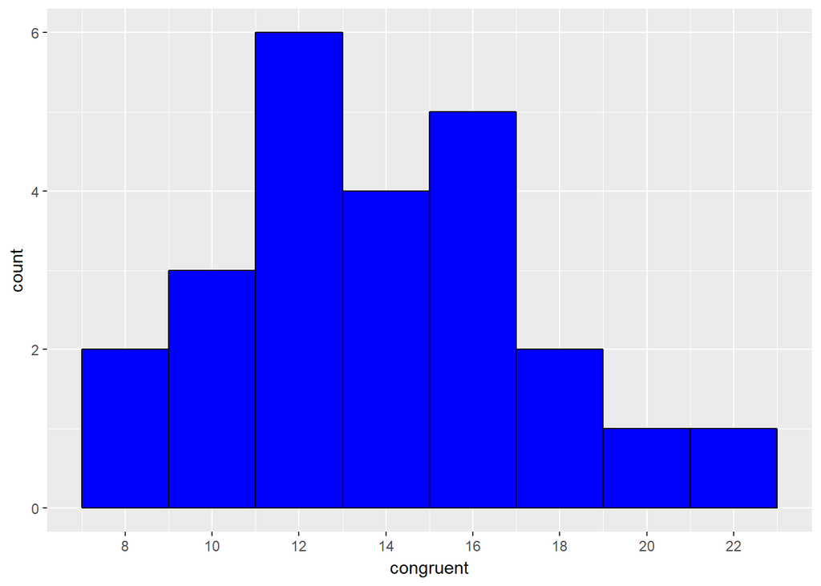

```r
library(ggplot2)
library(gridExtra)
c_vis <- ggplot(data=stroop, aes(x = congruent)) +
           geom_histogram(binwidth = 2,
                          fill = "blue",
                          color = "black") +
           scale_x_continuous(breaks = c(seq(8, 36, 2)))
c_vis
```

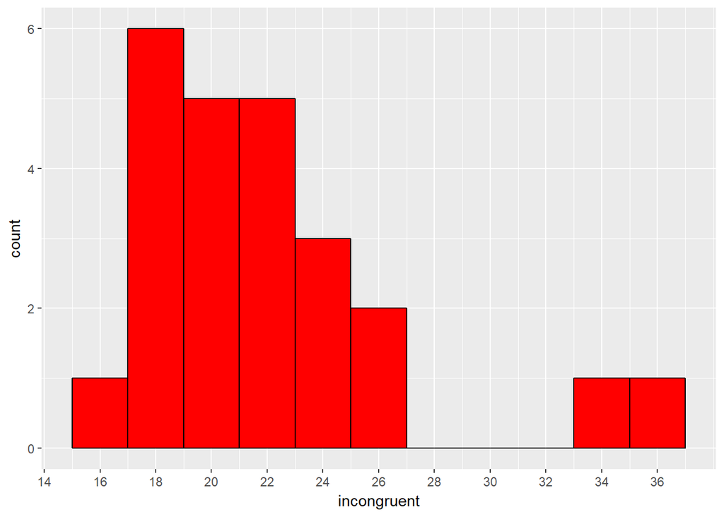

```r
ic_vis <- ggplot(data=stroop, aes(x = incongruent)) +
            geom_histogram(binwidth = 2,
                           fill = "red",
                           color = "black") +
            scale_x_continuous(breaks = c(seq(8, 36, 2)))
ic_vis
```

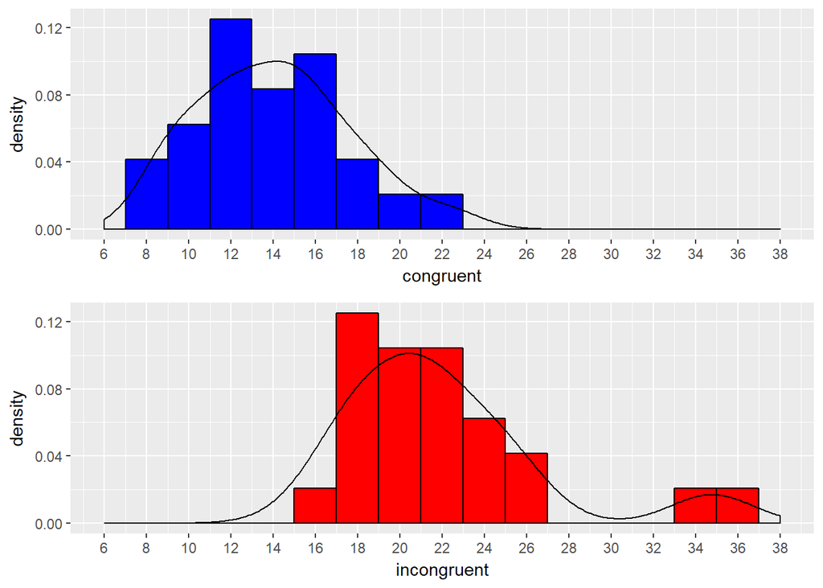

```r
c_vis <- ggplot(data=stroop, aes(x = congruent)) +
           geom_histogram(aes(y = ..density..),
                          binwidth = 2,
                          fill = "blue",
                          color = "black") +
           geom_density() +
           scale_x_continuous(limits = c(6, 38), breaks = c(seq(6, 38, 2)))

ic_vis <- ggplot(data=stroop, aes(x = incongruent)) +
            geom_histogram(aes(y = ..density..),
                           binwidth = 2,
                           fill = "red",
                           color = "black") +
            geom_density() +
            scale_x_continuous(limits = c(6, 38), breaks = c(seq(6, 38, 2)))

grid.arrange(c_vis, ic_vis)
```

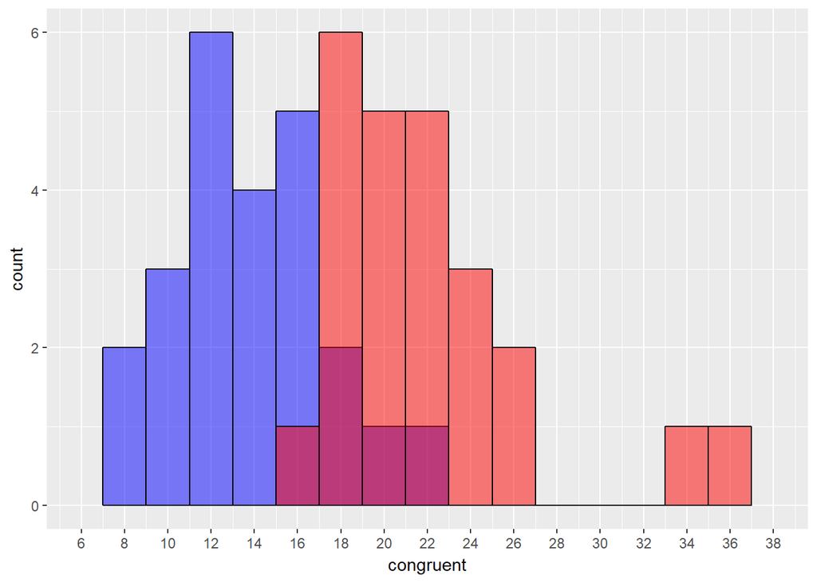

```r
ggplot(data = stroop, aes(x = congruent)) +
  geom_histogram(alpha = .5,
                 binwidth = 2,
                 fill = "blue",
                 color = "black") +
  geom_histogram(data = stroop,
                 aes(x = incongruent),
                 alpha = .5,
                 binwidth = 2,
                 fill = "red",
                 color = "black") +
  scale_x_continuous(limits = c(6, 38), breaks = c(seq(6, 38, 2)))
```

### Two-Tailed T-Test and Conclusion